# Practica1_datasauros_regresionLineal

## Regresión lineal sobre slant_up

En este gráfico se aplica un modelo de regresión lineal al subconjunto slant_up del conjunto datasaurus_dozen. La línea roja punteada representa la línea de tendencia que mejor ajusta los puntos en base a un modelo lineal simple (y = a + bx).

A pesar de que los puntos parecen tener una distribución con cierta inclinación visual, la línea de regresión es casi horizontal. Esto indica que, estadísticamente, la relación entre x e y es muy débil o nula desde la perspectiva del modelo lineal. Es decir, la pendiente es muy cercana a cero.

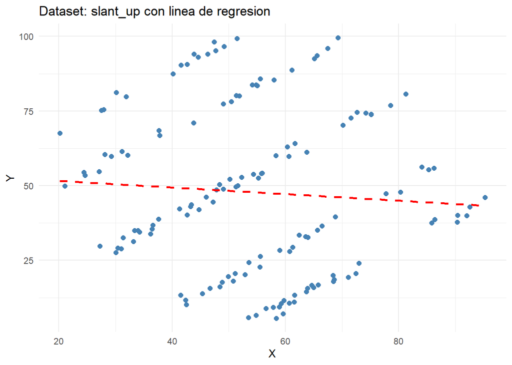

```r
datasaurus_dozen %>%
  filter(dataset == "slant_up") %>%
  ggplot(aes(x = x, y = y)) +
  geom_point(color = "steelblue", size = 2) +
  geom_smooth(method = "lm", se = FALSE, color = "red", linetype = "dashed") +
  theme_minimal() +
  labs(
    title = "Dataset: slant_up con linea de regresion",
    x = "X",
    y = "Y"
  )
```

## Predicción de regresión

Previamente, en clase se explicó cómo sería la regresión de *slant up*, la cual fue la siguiente:

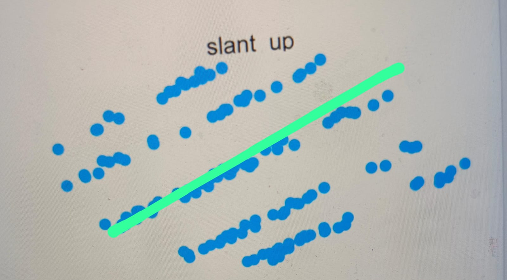

Prediccón de regresión